# Evaluation of the Stroop Phenomena

## A Walkthrough of a Basic T-Test.

This page presents a walkthrough of a basic T-Test. It's not meant to be an explanation of what T-tests do, just an illustration of how one can use Python, Pandas and other libraries in data analysis and visualization. But just to give a completely oversimplified explanation of a T-Test, and statisitics in general, you're trying to determine if a pattern that you're seeing in data is "real" or not, and you're trying to extrapolate from a small sample of data to make statements about the entire population.

So the data that we'll use is on the stroop effect. The stroop effect involves the mind's ability to differntiate text from visual queues. The basic test is to time people naming a list of colors that are the same color as the word,termed Congruent, or colored differently from the word, termed Incongruent. All this means is, how long does it take you to read these two lists? DO NOT read the word: Say the color of the letters!

#### Congruent:

**RED**  
**BLUE**  
**ORANGE**  
**GREEN**  
**PURPLE**  
**RED**

#### Incongruent:

**BLUE**  
**GREEN**  
**RED**  
**YELLOW**  
**ORANGE**  
**PURPLE**

If you're at all like me, your brain gets tripped up on the Incongruent list and you want to read the word instead of say the color. You can learn more about the Stroop Effect [here](https://faculty.washington.edu/chudler/words.html#seffect) and the dataset used in this analysis can be found [here](https://drive.google.com/file/d/0B9Yf01UaIbUgQXpYb2NhZ29yX1U/view).

So, now that you know what the Stroop Effect is, let's get started on the statistics. First, a few observations about the dataset, variable definitions, and so on:

1. **Question** What is our independent variable? What is our dependent variable?

   **Answer:** The independent variable is Congruent vs. Incongruent classification. The dependent variable is the time it takes to name the color of inks in a given length list.
2. **Question** What is an appropriate set of hypotheses for this task? What is the appropriate statistical test?

   **Answer:** Based on the times that I scored on the Stroop test, my hypotheses is that most people will find it more difficult to say the colors in the Incongurent list compared to the Congruent word list and therefore Incongruent times will be greater than Congruent Times. To put it more formally:

| Terms, Variables & Constants | Definition |
| --- | --- |
| H<sub>a</sub> | Hypothesis |
| H<sub>0</sub> | Null Hypothesis |
| $\mu_C$ | Population Mean of Congruent Times |
| $\mu_I$ | Population Mean of Incongruent Times |
| $\sigma_C$ | Population Standard deviation of Congruent Times |
| $\sigma_I$ | Population Standard deviation of Incongruent Times |
| $\hat{x}_C$ | Sample Mean of Congruent Times |
| $\hat{x}_I$ | Sample Mean of Incongruent Times |
| $S_C$ | Sample Standard deviation of Congruent Times |
| $S_I$ | Sample Standard deviation of Incongruent Times |
| $\alpha = 0.05$ | Critical Value used to test significance |
| n=24 | Sample size |
| $df = n-1$ | degrees of freedom |
| $SE $ | Standard Error: $SE = \frac{\sigma}{\sqrt{n}}$ |

> - *Hypothesis* **H<sub>a</sub>**: Population mean time of Incongruent data will be *significantly* greater than Population Mean time of Congruent data. $$\mu_I > \mu_C $$
> - *Null Hypothesis* **H<sub>0</sub>**: There will be no significant difference between Population Mean times of Congruent and Incongruent datasets. $$\mu_C = \mu_I $$

### Statistical Test:

- Because the dataset consists of a sample of paired data values - congruent and incongruent times for each test subject, a One-Sided Dependent T-test is appropriate.

**A T-test is appropriate because:**

1. The study is a within-subject design, and the dataset consists of dependent paired values
2. The dataset consists of a relatively small sample (n=24), and there is no data available to describe the population. Because of these two issues, a T-test is appropriate instead of a Z-test.
> - *Assumptions*:
>   1. The data is normally distributed, and therefore a T-test is valid.
>   2. A critical value of 0.05 will be used to test for significance.
>   3. A one sided test will be used based on anectdotal evidence from my own stroop test suggesting it is more time consuming to read Incongruent data than Congruent data.

### Data Investigation:

Lets bring the data into python and take a look!

```python
#import pandas and numpy to make life easier
import numpy as np
import pandas as pd
from pandas import Series, DataFrame
```

```python
# Read Stroopdata.csv into a DataFrame called StroopData. This code assumes the csv is in the working directory
# the csv is in the working directory.

StroopData = DataFrame(pd.read_csv("stroopdata.csv"))

# Now let's look at the data. The dataset is small enough to display in it's entirety.
StroopData
```

|  | Congruent | Incongruent |
| --- | --- | --- |
| 0 | 12.079 | 19.278 |
| 1 | 16.791 | 18.741 |
| 2 | 9.564 | 21.214 |
| 3 | 8.630 | 15.687 |
| 4 | 14.669 | 22.803 |
| 5 | 12.238 | 20.878 |
| 6 | 14.692 | 24.572 |
| 7 | 8.987 | 17.394 |
| 8 | 9.401 | 20.762 |
| 9 | 14.480 | 26.282 |
| 10 | 22.328 | 24.524 |
| 11 | 15.298 | 18.644 |
| 12 | 15.073 | 17.510 |
| 13 | 16.929 | 20.330 |
| 14 | 18.200 | 35.255 |
| 15 | 12.130 | 22.158 |
| 16 | 18.495 | 25.139 |
| 17 | 10.639 | 20.429 |
| 18 | 11.344 | 17.425 |
| 19 | 12.369 | 34.288 |
| 20 | 12.944 | 23.894 |
| 21 | 14.233 | 17.960 |
| 22 | 19.710 | 22.058 |
| 23 | 16.004 | 21.157 |

### Observation:

- This is a pretty simple dataset. Just two columns, Congruent and Incongruent, with each row representing the times for a given person.
- Visual inspection of the data suggests that a one sided test is appropriate. Incongruent times are consistently greater than congruent times so there is no need for a two-tailed test. We're just trying to determine if there is *significance* to the time difference.

### Basic Stats:

Now that we have the data in hand let's look at some basic statistics.

Pandas' describe() function provides a quick and easy way to look at your dataframe statistics:

- Note: describe() returns *sample* standard deviation with Bessel's Correction (n-1) applied.

```python
StroopData.describe()
```

|  | Congruent | Incongruent |
| --- | --- | --- |
| count | 24.000000 | 24.000000 |
| mean | 14.051125 | 22.015917 |
| std | 3.559358 | 4.797057 |
| min | 8.630000 | 15.687000 |
| 25% | 11.895250 | 18.716750 |
| 50% | 14.356500 | 21.017500 |
| 75% | 16.200750 | 24.051500 |
| max | 22.328000 | 35.255000 |

### Next, lets store mean and standard deviations for later use, and calculate IQR's

```python
precision = 3 #decimal places for rounding variables
x_C = round(np.mean(StroopData.Congruent), precision)
x_I = round(np.mean(StroopData.Incongruent),precision)

S_C = np.std(StroopData.Congruent, ddof=1) #ddof=1 uses bessel's correction n-1
S_I = np.std(StroopData.Incongruent, ddof=1)

#There's no doubt a funtion I don't know that calculates IQR, but this works too.
#so here's the IQR for Congruent Data:
IQR_C = StroopData.describe()["Congruent"]['75%'] - StroopData.describe()["Congruent"]['25%']
IQR_C = round(IQR_C, precision)
IQR_C, round(S_C,3)
```

```
(4.305, 3.559)
```

```python
#and the same for Incongruent:
IQR_I = StroopData.describe()["Incongruent"]['75%'] - StroopData.describe()["Incongruent"]['25%']
IQR_I = round(IQR_I, precision)
IQR_I, round(S_I, 3)
```

```
(5.335, 4.797)
```

So, just to highlight the differences between Congruent and Incongruent:

For Central Tendency measurments we have:

[output not shown]

For Variability measurments we have:

| Metric | Congruent | Incongruent |
| --- | --- | --- |
| Sample Std: | 3.56 | 4.80 |
| Sample IQR | 4.31 | 5.33 |

### Next, some visualizations:

I'm a huge fan of visualizing data. I think that the correct visualization can generate insights into your dataset that are much harder to grasp just from examining tables and metrics. Having said that, this dataset is simple enough that just a few plots will suffice:

```python
import pylab as plt
%pylab inline
```

```
WARNING: pylab import has clobbered these variables: ['plt']
`%matplotlib` prevents importing * from pylab and numpy
```

### Hmmm...

Not sure why I keep getting this warning. Some sort of interference between libraries. It turned up when I switched from importing **matplotlib** to **pylab** for plotting purposes. It has not affected the plots, so I'll just carry on...

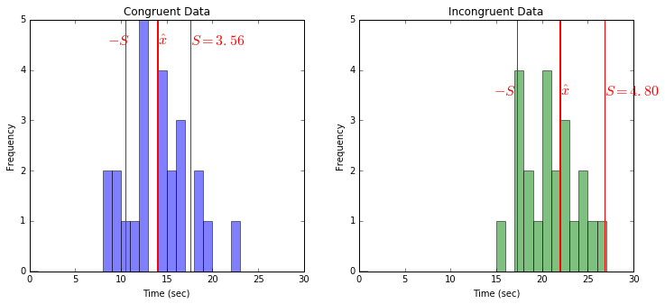

```python
fig, axes = plt.subplots(nrows=1, ncols=2, figsize=(12, 5)) #define subplot geometry

font = {'family': 'serif',
        'color':  'red',
        'weight': 'normal',
        'size': 16}

axes[0].hist(StroopData.Congruent, bins=30, range =[0,30],  alpha = 0.5)
axes[0].set_xlabel('Time (sec)')
axes[0].set_ylabel('Frequency')
axes[0].set_ylim(0,5)


# Add Vertical lines with labels for Mean and +/- 1 Standard Deviation
axes[0].axvline(x=x_C, linewidth=2, color='r') #Mean
axes[0].text(x_C, 4.5, r'$\hat{x}$', fontdict=font)

axes[0].axvline(x=(x_C + S_C), linewidth=1, color='r') #One Standard Dev
axes[0].text(x_C + S_C, 4.5, r'$S=3.56$', fontdict=font)

axes[0].axvline(x=(x_C - S_C), linewidth=1, color='r') #One Standard Dev
axes[0].text(8.5, 4.5, r'$-S$', fontdict=font)

axes[0].set_title("Congruent Data")


axes[1].hist(StroopData.Incongruent, bins=30,range=[0,30],facecolor = 'green', alpha = 0.5)
axes[1].set_xlabel('Time (sec)')
axes[1].set_ylabel('Frequency')
axes[1].set_ylim(0,5)

axes[1].axvline(x= x_I, linewidth=2, color='r') #Mean
axes[1].text(x_I, 3.5, r'$\hat{x}$', fontdict=font)

# Add Vertical lines with labels for Mean and Standard Deviation
axes[1].axvline(x = x_I + S_I, linewidth=1, color='r') #Plus One Standard Dev
axes[1].text(x_I + S_I, 3.5, r'$S=4.80$', fontdict=font)

axes[1].axvline(x = x_I - S_I, linewidth=1, color='r') #Minus 0ne Standard Dev
axes[1].text(14.75, 3.5, r'$-S$', fontdict=font) # Label
axes[1].set_title("Incongruent Data")
plt.show()
```

### Observations:

1. The first two histograms illustrate the different distributions of Congruent and Incongruent times with Means and 1st Standard Deviations marked by red vertical lines. the histograms suggest that these distributions are normal. The small size of the dataset (n=24) does result in some irregularity in the distributions but overal the apparant normal distribution of the data suggests that a T-test is valid.
2. Comparison of these histograms also illustrates the larger standard deviation for Incongruent data compared to Congruent Data.

### Combined data for comparison on the same Histogram

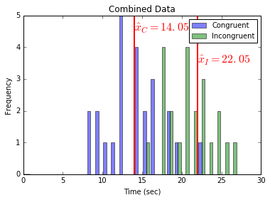

```python
labels = ['Congruent', 'Incongruent']
plt.hist([StroopData.Congruent, StroopData.Incongruent], bins=30, range=[0,30], alpha=0.5, label=labels)
plt.xlabel('Time (sec)')
plt.ylabel('Frequency')

plt.axvline(x = x_C, linewidth=2, color='r') #Mean
plt.text(x_C, 4.5, r'$\hat{x}_C=14.05$', fontdict=font)

plt.axvline(x = x_I, linewidth=2, color='r') #Incongruent Mean
plt.text(x_I, 3.5, r'$\hat{x}_I=22.05$', fontdict=font)

plt.title("Combined Data")
plt.legend(prop={'size': 10})
plt.show()
```

### Observations

- This histogram plots both Congruent and Incongruent Times.
- The plot illustrates that while there is some overlap in datasets from approximately 14 seconds to 22 seconds, thre is also a clear separation of sample means between Congruent and Incongruent times.

### Box and Violin Plots:

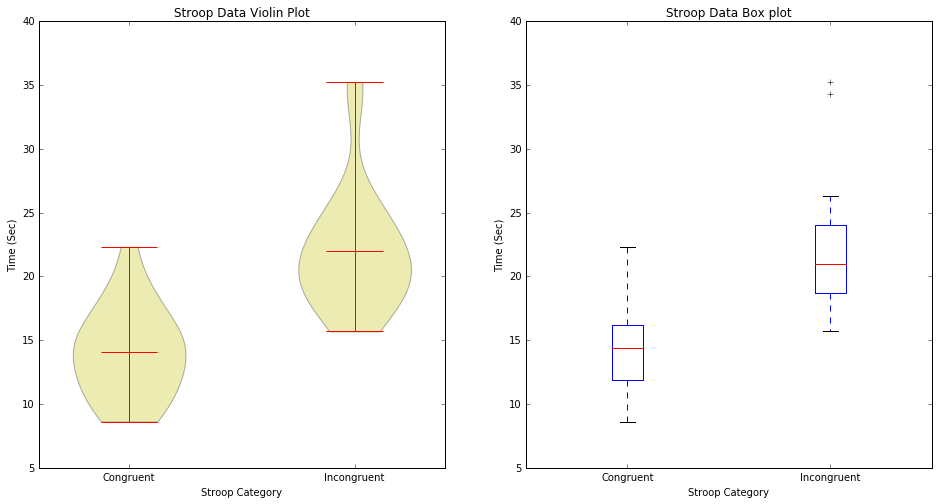

```python
#Configure subplot space for two plots
fig, axes = plt.subplots(nrows=1, ncols=2, figsize=(16, 8))

#Define Violin Plot
axes[0].violinplot([StroopData.Congruent, StroopData.Incongruent],
                   showmeans=True,
                   showmedians=False)
axes[0].set_title('Stroop Data Violin Plot')
axes[0].set_xlabel('Stroop Category')
axes[0].set_ylabel('Time (Sec)')

#Define Box Plot
axes[1].boxplot([StroopData.Congruent, StroopData.Incongruent])
axes[1].set_title('Stroop Data Box plot')
axes[1].set_xlabel('Stroop Category')
axes[1].set_ylabel('Time (Sec)')

#Label Categories on x axis
plt.setp(axes, xticks=[1,2],
         xticklabels=("Congruent","Incongruent"))



plt.show()
```

### Observations:

- Both plots draw atention to the two outliers in Incongruent times around 35 seconds.
- To my eye, the Violin plot emphasises the overlap in the datasets by highlighting the entire range of datasets, whereas the boxplot emphasises the discrepancies by highlighting IQR's
- The box plot also illustrates the larger IQR of the Incongruent Data.

### Statistical Test

Okay, we've got a pretty good idea of what the data looks like and it's pretty obvious that Incongruent times are greater than Congruent times. the next step is to apply the T-Test.

#### Analysis:

Since **$\hat{x}_C = 14.05$** and **$\hat{x}_I = 22.02$** we can state that: **$$ \hat{x}_I > \hat{x}_C$$**
Next, we must determine if this is a *significant* difference. The statistical meaning of *significant* can be paraphrased as "does it pass the appropriate statistical test for the given critical value?"

#### As stated above we will use a one sided T-Test to determine significance.

In a real analysis one would use scipy's ttest function to quickly get the answer, but we'll go through the test step by step here: To do this, first calculate the Point Estimate of the Differences between Congruent and Incongruent Times: **$\hat{x}_D = \hat{x}_I - \hat{x}_C = 22.02 - 14.05 = 7.97$**

The Calculations are below:

```python
## One sided T test.


x_D = x_I - x_C #calculate the mean of the differences:

alpha = .05 #Critical Value for T-test

n=24 #Samnple Size

df = n-1 # degrees of freedom

#To calculate Standard Deviation of the difference:
## First calculate the differnce and Variance values

StroopData['Difference'] = StroopData.Incongruent - StroopData.Congruent
StroopData['Variance'] = (StroopData.Difference -  x_D)**2

StroopData
```

|  | Congruent | Incongruent | Difference | Variance |
| --- | --- | --- | --- | --- |
| 0 | 12.079 | 19.278 | 7.199 | 0.586756 |
| 1 | 16.791 | 18.741 | 1.950 | 36.180225 |
| 2 | 9.564 | 21.214 | 11.650 | 13.579225 |
| 3 | 8.630 | 15.687 | 7.057 | 0.824464 |
| 4 | 14.669 | 22.803 | 8.134 | 0.028561 |
| 5 | 12.238 | 20.878 | 8.640 | 0.455625 |
| 6 | 14.692 | 24.572 | 9.880 | 3.667225 |
| 7 | 8.987 | 17.394 | 8.407 | 0.195364 |
| 8 | 9.401 | 20.762 | 11.361 | 11.532816 |
| 9 | 14.480 | 26.282 | 11.802 | 14.722569 |
| 10 | 22.328 | 24.524 | 2.196 | 33.281361 |
| 11 | 15.298 | 18.644 | 3.346 | 21.335161 |
| 12 | 15.073 | 17.510 | 2.437 | 30.558784 |
| 13 | 16.929 | 20.330 | 3.401 | 20.830096 |
| 14 | 18.200 | 35.255 | 17.055 | 82.628100 |
| 15 | 12.130 | 22.158 | 10.028 | 4.255969 |
| 16 | 18.495 | 25.139 | 6.644 | 1.745041 |
| 17 | 10.639 | 20.429 | 9.790 | 3.330625 |
| 18 | 11.344 | 17.425 | 6.081 | 3.549456 |
| 19 | 12.369 | 34.288 | 21.919 | 194.714116 |
| 20 | 12.944 | 23.894 | 10.950 | 8.910225 |
| 21 | 14.233 | 17.960 | 3.727 | 17.960644 |
| 22 | 19.710 | 22.058 | 2.348 | 31.550689 |
| 23 | 16.004 | 21.157 | 5.153 | 7.907344 |

```python
# Next calculate standard deviation of the differences:
S = sqrt(sum(StroopData.Variance)/df)
print 'S = ', round(S,3)
```

```
S =  4.865
```

### T-Statistic:

- The T-Statistic is calculated as the mean of the differences divided by the Standard Error:

### $t = \frac{\hat{x}_D}{\frac{S}{\sqrt{n}}}$

```python
t = x_D / (S/sqrt(n))
print't = %.3f / (%.3f / sqrt(%d)) = %.3f' %(x_D, S, n, t)
```

```
t = 7.965 / (4.865 / sqrt(24)) = 8.021
```

### Observation: This is a pretty big t value!

#### Next, calculate T-Critical:

- Remember that:  
  $\alpha = .05$  
  $df = 23$

#### I'll use **scipy's** probability density function to find $t_c$:

```python
from scipy.stats import t
```

```python
tAlpha = t.ppf(1-alpha, df) # use 1-alpha to return a positive t value.
round(tAlpha,3)
```

```
1.714
```

For Comparison, The [T-Value table](https://s3.amazonaws.com/udacity-hosted-downloads/t-table.jpg) confirms that for a one-sided significance test of $\alpha = 0.5$ with df=23 is $T_{critical} = 1.714$

#### Next, let's look at the probablity value of t:

- a T value of 8.021 is off the scale on the T-table linked above, which means it's pretty close to zero. Lets use **scipy** to see how small the probablity is

```python
#first double check that the probablity of tAlpha is .05
round(1 - t.cdf(tAlpha, df), 2)
```

```
0.05
```

```python
#Now look at the probablity value of t:
round(1-t.cdf(8.02, df),8)
```

```
2e-08
```

## Conclusion:

The t-value of 8.02 is significantly larger than the t-critical value of 1.714. **$$ t > t_\alpha$$**

In fact, the probablity value associated with t=8.02 is 2e-8, essentially zero. **$$ p(t) \approx 0 $$** Therefore we can reject the null Hypothesis **$H_0$** and accept the Alternative Hypothesis **$H_A$** that:
**$$\mu_I > \mu_C$$**

This suggests that, for the given dataset and assumptions, congruent and incongruent times compose separate populations, and it takes significantly longer to read incongruent lists than congruent lists.

Now, Having gone through all the math, let's use scipy's ttest function to find the p-value:

[output not shown]

```python
from scipy.stats import ttest_rel
```

```python
p = ttest_rel(StroopData.Congruent, StroopData.Incongruent)[1] * 2
print 'p = ',round(p, 8)
```

```
p =  8e-08
```

## Resources used in this Project

### Stroop Effect

- https://faculty.washington.edu/chudler/words.html#seffect

### Markdown

- https://github.com/adam-p/markdown-here/wiki/Markdown-Cheatsheet#lists
- http://www.statpower.net/Content/310/R%20Stuff/SampleMarkdown.html

### Plotting

- http://matplotlib.org/

### Numpy Documentation

- http://docs.scipy.org/doc/numpy-1.10.0/reference/generated/numpy.std.html